# Basic Processing & Visualizing

Xwyzworm

## Introduction :

It is now possible to collect a large amount of data about personal movement using activity monitoring devices such as a Fitbit, Nike Fuelband, or Jawbone Up. These type of devices are part of the “quantified self” movement – a group of enthusiasts who take measurements about themselves regularly to improve their health, to find patterns in their behavior, or because they are tech geeks. But these data remain under-utilized both because the raw data are hard to obtain and there is a lack of statistical methods and software for processing and interpreting the data.

This assignment makes use of data from a personal activity monitoring device. This device collects data at 5 minute intervals through out the day. The data consists of two months of data from an anonymous individual collected during the months of October and November, 2012 and include the number of steps taken in 5 minute intervals each day.

The data for this assignment can be downloaded from the course web site:

- Dataset: [Activity monitoring data](https://d396qusza40orc.cloudfront.net/repdata%2Fdata%2Factivity.zip)

The variables included in this dataset are:

steps: Number of steps taking in a 5-minute interval (missing values are coded as 𝙽𝙰)  
date: The date on which the measurement was taken in YYYY-MM-DD format  
interval: Identifier for the 5-minute interval in which measurement was taken  
The dataset is stored in a comma-separated-value (CSV) file and there are a total of 17,568 observations in this dataset.

## Processing DATA

Make sure you change the working directory

```r
setwd("D:/Reproducible Research/Week2")
```

Let’s Read & load The data then Check The summary

```r
activitydf <- read.csv("./DataSet/repdata_data_activity/activity.csv")
# Change Date to it's type
activitydf$date <- strptime(x = activitydf$date ,format = "%Y-%m-%d" )

print(cat("Step Null :" , sum(is.na(activitydf$steps)),
          "\nDate Null :" , sum(is.na(activitydf$date)),
          "\nInterval Null : ",sum(is.na(activitydf$interval))))
```

```
## Step Null : 2304
## Date Null : 0
## Interval Null :  0NULL
```

```r
str(activitydf)
```

```
## 'data.frame':    17568 obs. of  3 variables:
##  $ steps   : int  NA NA NA NA NA NA NA NA NA NA ...
##  $ date    : POSIXlt, format: "2012-10-01" "2012-10-01" ...
##  $ interval: int  0 5 10 15 20 25 30 35 40 45 ...
```

Because there’s N.A values , we’ll remove it for now ,since we want to get sense of data.

```r
CleanDf <- subset(activitydf , is.na(activitydf$steps) != T)

print(cat("Step Null :" , sum(is.na(CleanDf$steps)),
          "\nDate Null :" , sum(is.na(CleanDf$date)),
          "\nInterval Null : ",sum(is.na(CleanDf$interval))))
```

```
## Step Null : 0
## Date Null : 0
## Interval Null :  0NULL
```

```r
str(activitydf)
```

```
## 'data.frame':    17568 obs. of  3 variables:
##  $ steps   : int  NA NA NA NA NA NA NA NA NA NA ...
##  $ date    : POSIXlt, format: "2012-10-01" "2012-10-01" ...
##  $ interval: int  0 5 10 15 20 25 30 35 40 45 ...
```

## What is the total number of steps taken each day ?

let’s Build Histogram for total number of steps taken each day using the Clean Dataset

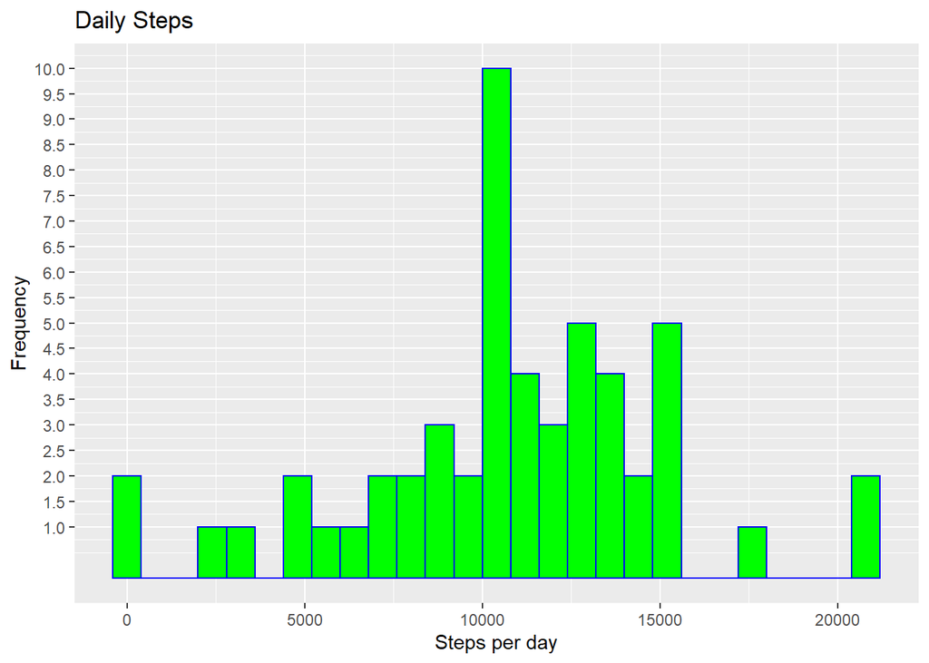

```r
# We're Aggregating the step using Sum function
TotalStepstaken <- aggregate(x = CleanDf$steps , by = list(as.Date(CleanDf$date)) , FUN = sum)
names(TotalStepstaken) <- c("date", "total")

library(ggplot2)
ggplot2::ggplot( data = TotalStepstaken , aes(x = total))+
        ggplot2::geom_histogram(binwidth = 800 , fill = "green" ,col ="blue") +
        ggplot2::labs(x = "Steps per day" , y = "Frequency" , title = "Daily Steps") +
        ggplot2::scale_y_continuous(breaks = seq(1,10 ,by =0.5))
```

We can that per each day there’s alot steps per day ,we can say that roughly 10000 - 11000 steps each day. What about the mean ? Let’s Check it out

```r
with(TotalStepstaken , {
        mean_steps = mean(total ,na.rm = T)
        Median_steps = median(total , na.rm = T)
        cat(paste("Mean : " , mean_steps ,
                  "\nMedian : " , Median_steps))}
)
```

```
## Mean :  10766.1886792453
## Median :  10765
```

Just like what i thought before :D .

##What is the average daily activity interval ?

So Now ,we’re going to to doing aggregate again

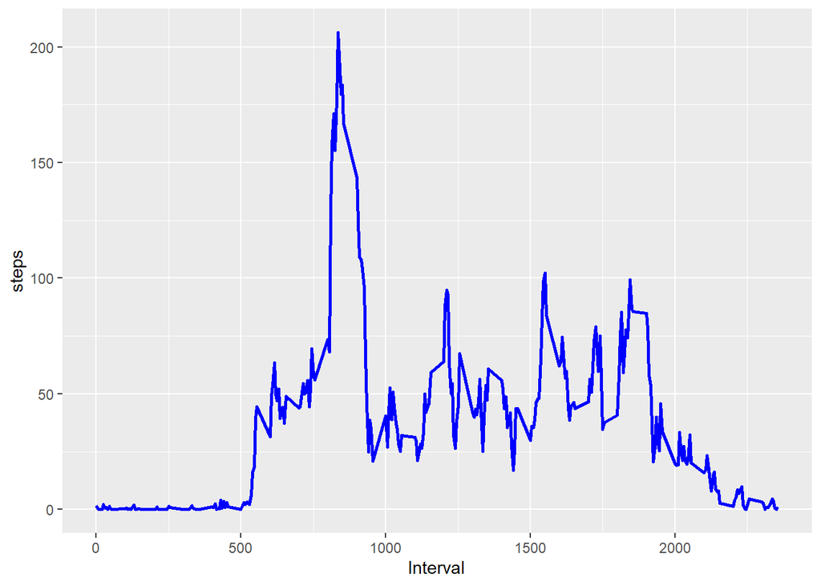

```r
AverageSteptaken <- aggregate(x = CleanDf$steps , by = list(CleanDf$interval) ,
                              FUN = mean)
names(AverageSteptaken) <- c("Interval" , "steps" )
ggplot2::ggplot(data = AverageSteptaken ,
                aes(x =Interval, y = steps)) +
        ggplot2::geom_line(size = 1 ,col = "blue" )
```

We can see that ,its going up very between 700 and 850 i guess.Then drop down and it’s unstable again. It’s worth to know what cause the high steps on that interval,but we’re not going to do dat. But here’s the Max average steps on interval x.

```r
AverageSteptaken[AverageSteptaken$steps == max(AverageSteptaken$steps), "Interval"]
```

```
## [1] 835
```

## Working with Missing Values

So now we’re working with missing values . We Can Use Median / Mean Tho no need to be sophiscated right now. But We will use median , because the data skewed.

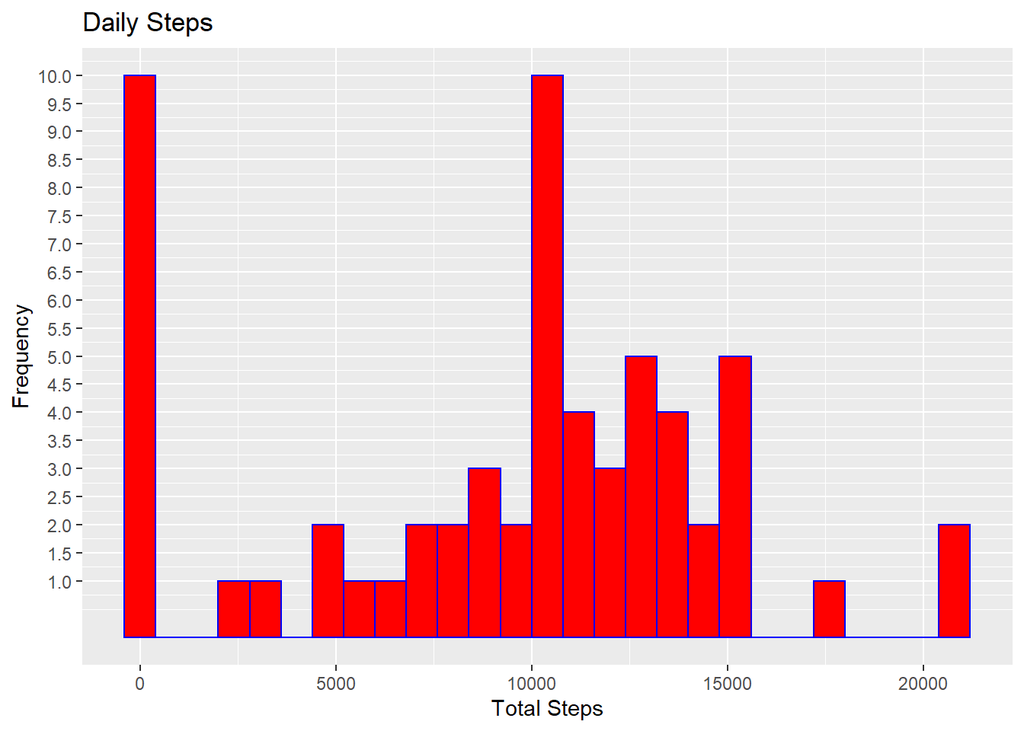

```r
activitydf[is.na(activitydf$steps) == T ,"steps"] <- median(activitydf$steps,na.rm =T)

# Let's Check The Previous Histogram with imputed missing values
TotalStepstaken <- stats::aggregate(x = activitydf$steps , by = list(as.Date(activitydf$date)),
                                    FUN = sum)
names(TotalStepstaken) <- c("date" , "total")
ggplot2::ggplot(data = TotalStepstaken ,
                aes(x = total)) +
        geom_histogram(binwidth = 800 , col = "blue" , fill = "red") +
        labs( title = "Daily Steps", x = "Total Steps" , y = "Frequency" ) +
        ggplot2::scale_y_continuous(breaks = seq(1,10 ,by =0.5))
```

## Now We will compare the weekEnd And Weekdays , doing god’s work now .

```r
weekday <- base::weekdays(x = activitydf$date)
unique(weekday)
```

```
## [1] "Monday"    "Tuesday"   "Wednesday" "Thursday"  "Friday"    "Saturday"
## [7] "Sunday"
```

```r
activitydf[grepl(pattern = "Monday|Tuesday|Wednesday|Thursday|Friday|" , x = weekday) , 'Weekdays'] <- "weekday"
activitydf[grepl(pattern = "Saturday|Sunday", x = weekday) , 'Weekend'] <- "weekend"
activitydf$WeekDaysOrEnd <- paste(activitydf$Weekdays,activitydf$Weekend)
activitydf$WeekDaysOrEnd[activitydf$WeekDaysOrEnd == "weekday NA"] <- "weekday"
activitydf$WeekDaysOrEnd[activitydf$WeekDaysOrEnd == "weekday weekend"] <- "weekend"
activitydf <- activitydf[, c(1,2,3,6)]
activitydf$day <- weekday

str(activitydf)
```

```
## 'data.frame':    17568 obs. of  5 variables:
##  $ steps        : num  0 0 0 0 0 0 0 0 0 0 ...
##  $ date         : POSIXlt, format: "2012-10-01" "2012-10-01" ...
##  $ interval     : int  0 5 10 15 20 25 30 35 40 45 ...
##  $ WeekDaysOrEnd: chr  "weekday" "weekday" "weekday" "weekday" ...
##  $ day          : chr  "Monday" "Monday" "Monday" "Monday" ...
```

Now we will build the plots

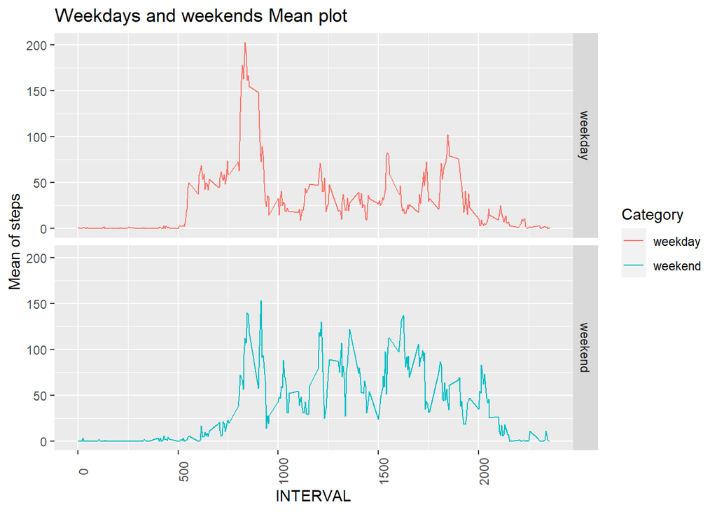

```r
AverageDaysEnd <- aggregate(x = activitydf$steps ,
                            by = list(activitydf$interval , activitydf$WeekDaysOrEnd),
                            FUN = mean)
names(AverageDaysEnd) <- c("interval","weekEndORDays","meanStep")
ggplot2::ggplot(data = AverageDaysEnd , aes(x = interval , y = meanStep ,col= weekEndORDays ))+
        geom_line() +
        facet_grid(weekEndORDays ~ .) +
        labs(x = "INTERVAL" , y ="Mean of steps" ,title = "Weekdays and weekends Mean plot") +
        guides(col = guide_legend(title = "Category")) +
        theme(axis.text.x = element_text(angle = 90))
```

As you can see there’s something weirdos on weekday plot that outlier ,while weekend seems normal .